# Coursework Output 2

*Instructions*: In this coursework, you will show your domain of the data related Python skills required for business analytics. To do so, you will use packages such as *numpy* and *matplotlib*.

## Importing and Visualising a Dataset in Python

Each student will be assigned a different dataset in a *comma separated value* (*.csv*) format. The main goal is to import such dataset into Python so that you can wrangle and visualise the data in better ways. This will allow you to get your own conclusions and start building up knowledge regarding on how you could potentially learn from data to predict or classify future instances.

You must create a program which allows you to select from the following options:

1. Import and print your dataset into Python as a numpy array.
2. Query and print an instance of the dataset by row number or by id (i.e. first column of the table).
3. Create a "reduced" dataset (i.e. with less columns) by indicating a list of column names to bring upon this newly created dataset.
4. Plot the dataset by means of a scatterplot which relates two columns specified by the user. The plot has to show the $x$ and $y$ axis labels as the chosen columns, and use the *target/class* column (i.e. the last one) as the colour variable.
5. Exit the program.

## Additional Considerations

- The program has to check that every input is valid.
- No option (except for exit) can be executed until option 1 is executed first.

## Submission Instructions

- Once that you have finished your program, run all cells and run the main program cell using the following sequence of options: 0(wrong option),2(has to fail),1,2(by row index),2(by row name),3,4,5.
- Then, without clearing the kernel, generate a html **OR** pdf file from the Jupyter notebook.
- Clear the Jupyter notebook kernel, then name both the Jupyter notebook and the html/pdf files with your id number and submit them to the corresponding Moodle's dropbox before **12th December, 2019**.

```python
!pip install scipy
```

```python
## Use this cell to import all necessary packages
import numpy as np
import csv
import matplotlib.pyplot as plt
```

```python
## Use this cell to define the function corresponding to OPTION 1
def option1():
    '''With this function you import the dataset into a numpy array.'''
    with open('traffic.csv') as csvfile:
        data1 = csv.reader(csvfile, delimiter=',')
        headers = next(data1)
        maindata = list(data1)
        maindata = np.array(maindata).astype(float)
    print(headers)
    print(maindata)
    return maindata, headers
```

```python
## Use this cell to define the function corresponding to OPTION 2
def option2(data,header):
    '''This function queries and prints a row of the dataset (by row number or id).'''
    print("would you like to search the data set by row number or id number?")
    print("enter 0 for ID number and 1 for row index")
    searchmethod = input()
    check = ['0','1']
    flag = False
    if searchmethod not in check:
        print("not valid \n returning to main menu")

    else:
        while flag == False:
            if searchmethod == '0':
                print('please enter the street ID number')
                try:
                    ID = int(input())
                    row = data[np.where(data[:,0]==ID)]
                    print(row)
                    flag = True
                except:
                    print("this street id can't be found")
            else:
                lengh = len(data)
                print('please enter the row index.  The index starts at 0 and goes to', lengh-1)
                try:
                    rownumber = int(input())
                    print (data[rownumber])
                    flag = True
                except:
                    print("Not in range. \n enter an integer between 1 and", lengh -1)
    return
```

```python
## Use this cell to define the function corresponding to OPTION 3
def option3(data,header):
    '''This function creates a new dataset by indicating which columns to include.'''
    newcolumns =[]
    flag =False
    while flag == False:
        print("enter a column that you want on the reduced data set")
        print(header)

        column = input()
        column = column.lower()
        if column in header:

            position = header.index(column)
            newcolumns.append(position)
            flag2 = False
            while flag2 == False:
                print("would you like to add more columns? y/n")
                answer = input()
                answer = answer.lower()

                if answer == "n":
                    flag = True
                    flag2 = True
                    reduceddata = data[:,[newcolumns]]
                    print(reduceddata)
                elif answer == "y":
                    flag2 = True
                else:
                    print ('this is not a valid answer. \n y for yes \n n for no')

        else:
            print('this is not a valid header name')
            print('would you like to try again? \n enter y to try again or any other key to exit to the main menu')
            reply = input()
            reply = reply.lower()
            if reply != 'y':
                flag = True


    return
```

```python
## Use this cell to define the function corresponding to OPTION 4
def option4(data,headings):
    '''This function visualises the dataset using a scatterplot.'''
    flagx = 0
    while flagx == 0:
        print("please enter the variable to plot on the x-axis")
        print("For average vehicles per day choose 1")
        print("For latitude choose 2")
        print("For longitude choose 3")
        check = ["1","2","3"]
        x= input()

        if x not in check:
            print("not valid")

        else:
            x = int(x)
            flagx = 1
    flagy = 0
    while flagy == 0:

        print("please enter the variable to plot on the y-axis")
        print("For average vehicles per day choose 1")
        print("For latitude choose 2")
        print("For longitude choose 3")
        y= input()
        if y not in check:
            print("not valid")

        else:
            y = int(y)
            flagy = 1

    plt.scatter(data[:,x],data[:,y], c= data[:,-1])
    plt.xlabel(headings[x])
    plt.ylabel(headings[y])
    plt.show()
    return
```

```python
##### Use this cell to create the "main" part of your program
print("Welcome to **Shona Hutchinson 9807717** business case.")
option = True
opt1Flag = False
while option:
    print("Select an option \nPlease enter 1 to 5")
    option = input()
    if option == '1':
        data, header =option1()
        opt1Flag = True

    elif option == '5':
            print("exiting program")
            option = False

    elif opt1Flag == False and option in ['2','3','4']:

            print("option 1 needs to be selected before any other option. Please try again")

    elif option == '2':
        option2(data,header)

    elif option == '3':
        option3(data,header)
    elif option == '4':

        option4(data,header)


    else:
        print("invalid option")
```

```
Welcome to **Shona Hutchinson 9807717** business case.
Select an option
Please enter 1 to 5

invalid option
```

**If I insert an empty invalid option, the program does not offer a second chance.**

```python
##### Use this cell to create the "main" part of your program
print("Welcome to **Shona Hutchinson 9807717** business case.")
option = True
opt1Flag = False
while option:
    print("Select an option \nPlease enter 1 to 5")
    option = input()
    if option == '1':
        data, header =option1()
        opt1Flag = True

    elif option == '5':
            print("exiting program")
            option = False

    elif opt1Flag == False and option in ['2','3','4']:

            print("option 1 needs to be selected before any other option. Please try again")

    elif option == '2':
        option2(data,header)

    elif option == '3':
        option3(data,header)
    elif option == '4':

        option4(data,header)


    else:
        print("invalid option")
```

```
Welcome to **Shona Hutchinson 9807717** business case.
Select an option
Please enter 1 to 5
potato
invalid option
Select an option
Please enter 1 to 5
6
invalid option
Select an option
Please enter 1 to 5
2
option 1 needs to be selected before any other option. Please try again
Select an option
Please enter 1 to 5
1
['street id', 'average vehicles per day', 'latitude', 'longitude', 'traffic size']
[[ 2.0000000e+00  1.4600000e+04  4.1764877e+01 -8.7666635e+01
   1.0000000e+00]
 [ 3.0000000e+00  1.6500000e+04  4.1765008e+01 -8.7657067e+01
   1.0000000e+00]
 [ 9.0000000e+00  8.6000000e+03  4.1766260e+01 -8.7574226e+01
   0.0000000e+00]
 ...
 [ 1.3700000e+03  2.4700000e+04  4.1767951e+01 -8.7576347e+01
   2.0000000e+00]
 [ 1.3750000e+03  6.8000000e+03  4.1710698e+01 -8.7632871e+01
   0.0000000e+00]
 [ 1.3760000e+03  6.4000000e+03  4.1994513e+01 -8.7663898e+01
   0.0000000e+00]]
Select an option
Please enter 1 to 5
2
would you like to search the data set by row number or id number?
enter 0 for ID number and 1 for row index

not valid
 returning to main menu
Select an option
Please enter 1 to 5
```

[output cut: 14 more lines]

```
enter 0 for ID number and 1 for row index
0
please enter the street ID number
potato
this street id can't be found
please enter the street ID number

this street id can't be found
please enter the street ID number
99
[]
Select an option
Please enter 1 to 5
5
exiting program
```

**When I selected an invalid street id, the program returned an empty list/numpy array instead of a warning message**

```
Welcome to **Shona Hutchinson 9807717** business case.
Select an option
Please enter 1 to 5
1
['street id', 'average vehicles per day', 'latitude', 'longitude', 'traffic size']
[[ 2.0000000e+00  1.4600000e+04  4.1764877e+01 -8.7666635e+01
   1.0000000e+00]
 [ 3.0000000e+00  1.6500000e+04  4.1765008e+01 -8.7657067e+01
   1.0000000e+00]
 [ 9.0000000e+00  8.6000000e+03  4.1766260e+01 -8.7574226e+01
   0.0000000e+00]
 ...
 [ 1.3700000e+03  2.4700000e+04  4.1767951e+01 -8.7576347e+01
   2.0000000e+00]
 [ 1.3750000e+03  6.8000000e+03  4.1710698e+01 -8.7632871e+01
   0.0000000e+00]
 [ 1.3760000e+03  6.4000000e+03  4.1994513e+01 -8.7663898e+01
   0.0000000e+00]]
Select an option
Please enter 1 to 5
2
would you like to search the data set by row number or id number?
enter 0 for ID number and 1 for row index
0
please enter the street ID number
2
[[ 2.0000000e+00  1.4600000e+04  4.1764877e+01 -8.7666635e+01
   1.0000000e+00]]
Select an option
Please enter 1 to 5
2
would you like to search the data set by row number or id number?
enter 0 for ID number and 1 for row index
1
please enter the row index.  The index starts at 0 and goes to 342

Not in range.
 enter an integer between 1 and 342
please enter the row index.  The index starts at 0 and goes to 342
-1
```

[output cut: 68 more lines]

```

 [[1376.       1376.         41.994513]]]
Select an option
Please enter 1 to 5
4
please enter the variable to plot on the x-axis
For average vehicles per day choose 1
For latitude choose 2
For longitude choose 3
2
please enter the variable to plot on the y-axis
For average vehicles per day choose 1
For latitude choose 2
For longitude choose 3
3
```

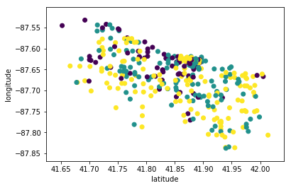

```
Select an option
Please enter 1 to 5
5
exiting program
```

```python
##### Use this cell to create the "main" part of your program
print("Welcome to **Shona Hutchinson 9807717** business case.")
option = True
opt1Flag = False
while option:
    print("Select an option \nPlease enter 1 to 5")
    option = input()
    if option == '1':
        data, header =option1()
        opt1Flag = True

    elif option == '5':
            print("exiting program")
            option = False

    elif opt1Flag == False and option in ['2','3','4']:

            print("option 1 needs to be selected before any other option. Please try again")

    elif option == '2':
        option2(data,header)

    elif option == '3':
        option3(data,header)
    elif option == '4':

        option4(data,header)


    else:
        print("invalid option")
```

## Questions

Please answer the following questions to appraise your level of engagement with the content of the course. Use the Markdown cell corresponding to each question to write your answers.

1. Is there any other data structure or module in Python (besides *numpy*) which would allow you to import a *.csv* file in a more practical and manageable way? Use a code cell to support your answer.

**ANSWER:**

The data can be imported into a pandas DataFrame structure. One thing that makes it more manageable is the header index.

```python
## Use this cell to import your dataset with a data structure other than numpy

import pandas as pd
pandasdata = pd.read_csv('traffic.csv')
print(pandasdata)
```

```
     street id  average vehicles per day   latitude  longitude  traffic size
0            2                     14600  41.764877 -87.666635             1
1            3                     16500  41.765008 -87.657067             1
2            9                      8600  41.766260 -87.574226             0
3           10                     10000  41.739836 -87.551476             1
4           14                     10800  41.820171 -87.606798             1
5           18                     19100  41.775779 -87.605826             1
6           25                     15300  41.854926 -87.675920             1
7           29                      7000  41.827625 -87.675208             0
8           31                     10900  41.803741 -87.674569             1
9           36                     19900  41.838419 -87.617465             1
10          45                      7400  41.750400 -87.552800             0
11          55                      4400  41.787779 -87.620665             0
12          60                     24300  41.761454 -87.576196             2
13          66                     18100  41.849344 -87.618459             1
```

[output cut: 49 more lines]

1. Using any of the two continuous variables of your dataset, using a cell code show an example of how a **linear regression** could be applied with your dataset to predict the values of future entries of data without target/class (you can implement linear regressions using existing Python modules). Moreover, discuss if there is any metric that can be used to decide which two variables are the most correlated.

**ANSWER:**

The polyfit takes the the x and y data as input and returns the constant and the slope. (m & b in the equation y = mx + b) R- Squared (the coefficient of determination ) can be used to decide which 2 variables are most correlated. The value of R-Squared ranges from 0 to 1. The closer to 1 the better the regression line equation explains the relationship between the 2 variables. If R-Squared was exactly 1 then for all the observed data, the dependent variable y always sits exactly on the regression line.

The pearsonr class returns the person r coefficient which is the square root of R Squared. There is not much of a correlation between any of the 3 variables but the strongest is between latitude and longitude which has a weak negative relationship. (R Squared is 0.29)

At the end of the code cell below it will ask for an x value for which to predict a value for y using the equation of the regression line. However as the R Squared vales are so weak it's not actually worth bothering with.

```
['street id', 'average vehicles per day', 'latitude', 'longitude', 'traffic size']
[[ 2.0000000e+00  1.4600000e+04  4.1764877e+01 -8.7666635e+01
   1.0000000e+00]
 [ 3.0000000e+00  1.6500000e+04  4.1765008e+01 -8.7657067e+01
   1.0000000e+00]
 [ 9.0000000e+00  8.6000000e+03  4.1766260e+01 -8.7574226e+01
   0.0000000e+00]
 ...
 [ 1.3700000e+03  2.4700000e+04  4.1767951e+01 -8.7576347e+01
   2.0000000e+00]
 [ 1.3750000e+03  6.8000000e+03  4.1710698e+01 -8.7632871e+01
   0.0000000e+00]
 [ 1.3760000e+03  6.4000000e+03  4.1994513e+01 -8.7663898e+01
   0.0000000e+00]]
-70.89938792354121 -0.4006794964075985
```

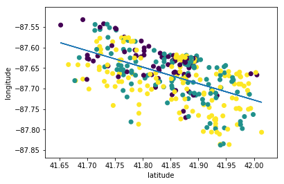

```
the regresion equation is y = -0.4006794964075985 * x + -70.89938792354121
r =  -0.5386091222278291
r squared is 0.29009978654703256
enter a value for x latitude
42
the estimated y value for longitude  is -87.72792677266035
```

```python
## Use this cell to implement a linear regression between two variables
from scipy import stats
data, headings =option1()

colx = 2 #This relates to the column in the numpy array to use as x values
coly = 3 #This relates to the column in the numpy array to use as y values
m, b = np.polyfit(data[:,colx],data[:,coly],1)
print(b,m)
plt.scatter(data[:,colx],data[:,coly], c= data[:,-1])
plt.xlabel(headings[colx])
plt.ylabel(headings[coly])
plt.plot(data[:,colx],data[:,colx]*m +b)
plt.show()

print("the regresion equation is y =",m,"* x +",b)
r,p = stats.pearsonr(data[:,colx],data[:,coly])
print("r = ", r)
rsquared = r* r
print("r squared is",rsquared)
print("enter a value for x",headings[colx])
try:
    xvalue =float(input())
    yvalue = xvalue *m +b
    print("the estimated y value for",headings[coly]," is",yvalue )
except:
    print("not a valid number")
```